# Transfer Learning with Convolutional Neural Networks For Classification with Keras

Here, an image classifier will be built using the VGG16 pre-trained model (transfer learning), and will be evaluated on a validation dataset. Finally, predictions will be assessed. A binary classification will be achieved to assess crack detection in concrete from images (positive images=cracked, negative=concrete).

Created on Watson Studio

## Table of Contents

1. Data
2. Libraries
3. Network construction and training
4. Model evaluation
5. Predictions

Created on IBM Watson Studio

## Data

```python
#! wget https://s3-api.us-geo.objectstorage.softlayer.net/cf-courses-data/CognitiveClass/DL0321EN/data/concrete_data_week4.zip
```

```python
#! wget https://s3-api.us-geo.objectstorage.softlayer.net/cf-courses-data/CognitiveClass/DL0321EN/data/concrete_data_week3.zip
```

```python
#!unzip -q concrete_data_week4.zip
#!unzip -q concrete_data_week3.zip
```

## Libraries

```python
#!pip install skillsnetwork
```

```python
import skillsnetwork
```

```python
from keras.preprocessing.image import ImageDataGenerator
import keras
from keras.models import Sequential
from keras.layers import Dense
```

```python
from keras.applications import VGG16
from keras.applications.vgg16 import preprocess_input
```

## Network and training

**Here are instructions to build the Network:**

1. Use a batch size of 100 images for both training and validation.
2. Construct an ImageDataGenerator for the training set and another one for the validation set. VGG16 was originally trained on 224 × 224 images, so make sure to address that when defining the ImageDataGenerator instances.
3. Create a sequential model using Keras. Add VGG16 model to it and dense layer.
4. Compile the mode using the adam optimizer and the categorical_crossentropy loss function.
5. Fit the model on the augmented data using the ImageDataGenerators.
1. We are dealing with two classes, so *num_classes* is 2.
2. The VGG16 model was built and trained using images of size (224 x 224). Therefore, we will have to resize our images from (227 x 227) to (224 x 224).
3. We will training and validating the model using batches of 100 images.

```python
num_classes = 2
image_resize = 224
batch_size_training = 100
batch_size_validation = 100
```

### Construct ImageDataGenerator Instances

```python
data_generator = ImageDataGenerator(preprocessing_function=preprocess_input)
```

Next, we will use the *flow_from_directory* method to get the training images as follows:

```python
train_generator = data_generator.flow_from_directory(
    'concrete_data_week3/train',
    target_size=(image_resize, image_resize),
    batch_size=batch_size_training,
    class_mode='categorical')
```

```
Found 30001 images belonging to 2 classes.
```

```python
validation_generator = data_generator.flow_from_directory(
    'concrete_data_week3/valid',
    target_size=(image_resize, image_resize),
    batch_size=batch_size_validation,
    class_mode='categorical')
```

```
Found 10001 images belonging to 2 classes.
```

We will start building our model. We will use the Sequential model class from Keras.

```python
model = Sequential()
```

Next, we will add the VGG16 pre-trained model to out model. However, note that we don't want to include the top layer or the output layer of the pre-trained model. We actually want to define our own output layer and train it so that it is optimized for our image dataset. In order to leave out the output layer of the pre-trained model, we will use the argument *include_top* and set it to **False**.

```python
model.add(VGG16(include_top=False,pooling='avg', weights='imagenet'))
```

```
Downloading data from https://storage.googleapis.com/tensorflow/keras-applications/vgg16/vgg16_weights_tf_dim_ordering_tf_kernels_notop.h5
```

Then, we will define our output layer as a **Dense** layer, that consists of two nodes and uses the **Softmax** function as the activation function.

```python
model.add(Dense(num_classes, activation='softmax'))
```

You can access the model's layers using the *layers* attribute of our model object.

```python
model.layers
```

```
[<keras.engine.functional.Functional at 0x7f253811ac50>,
 <keras.layers.core.dense.Dense at 0x7f2539016950>]
```

You can see that our model is composed of two sets of layers. The first set is the layers pertaining to VGG16 and the second set is a single layer, which is our Dense layer that we defined above.

You can access the VGG16 layers by running the following:

```python
model.layers[0].layers
```

```
[<keras.engine.input_layer.InputLayer at 0x7f253a39dde0>,
 <keras.layers.convolutional.conv2d.Conv2D at 0x7f253a3f1a20>,
 <keras.layers.convolutional.conv2d.Conv2D at 0x7f25380fd4e0>,
 <keras.layers.pooling.max_pooling2d.MaxPooling2D at 0x7f25380fcbb0>,
 <keras.layers.convolutional.conv2d.Conv2D at 0x7f25380fdd80>,
 <keras.layers.convolutional.conv2d.Conv2D at 0x7f25380ff130>,
 <keras.layers.pooling.max_pooling2d.MaxPooling2D at 0x7f25380fdb40>,
 <keras.layers.convolutional.conv2d.Conv2D at 0x7f25380fc880>,
 <keras.layers.convolutional.conv2d.Conv2D at 0x7f25380fc160>,
 <keras.layers.convolutional.conv2d.Conv2D at 0x7f2538118700>,
 <keras.layers.pooling.max_pooling2d.MaxPooling2D at 0x7f253811a8c0>,
 <keras.layers.convolutional.conv2d.Conv2D at 0x7f253811b3d0>,
 <keras.layers.convolutional.conv2d.Conv2D at 0x7f253811b940>,
 <keras.layers.convolutional.conv2d.Conv2D at 0x7f253811a6e0>,
 <keras.layers.pooling.max_pooling2d.MaxPooling2D at 0x7f253811b460>,
 <keras.layers.convolutional.conv2d.Conv2D at 0x7f2538119a80>,
 <keras.layers.convolutional.conv2d.Conv2D at 0x7f25381197b0>,
 <keras.layers.convolutional.conv2d.Conv2D at 0x7f25ae963070>,
 <keras.layers.pooling.max_pooling2d.MaxPooling2D at 0x7f25380fe830>,
 <keras.layers.pooling.global_average_pooling2d.GlobalAveragePooling2D at 0x7f25380ffe80>]
```

Since the VGG16 model has already been trained, then we want to tell our model not to bother with training the VGG16 part, but to train only our dense output layer. To do that, we run the following.

```python
model.layers[0].trainable = False
```

And now using the *summary* attribute of the model, we can see how many parameters we will need to optimize in order to train the output layer.

```python
model.summary()
```

```
Model: "sequential"
_________________________________________________________________
 Layer (type)                Output Shape              Param #
=================================================================
 vgg16 (Functional)          (None, 512)               14714688

 dense (Dense)               (None, 2)                 1026

=================================================================
Total params: 14,715,714
Trainable params: 1,026
Non-trainable params: 14,714,688
_________________________________________________________________
```

Next we compile our model using the **adam** optimizer.

```python
model.compile(optimizer='adam', loss='categorical_crossentropy', metrics=['accuracy'])
```

Before we are able to start the training process, with an ImageDataGenerator, we will need to define how many steps compose an epoch. Typically, that is the number of images divided by the batch size. Therefore, we define our steps per epoch as follows:

```python
steps_per_epoch_training = len(train_generator)
steps_per_epoch_validation = len(validation_generator)
num_epochs = 1 #To reduce computation cost, the number of epochs is reduced to 1. Feel free to add epochs to better optimize the model.
```

Finally, we are ready to start training our model. Unlike a conventional deep learning training were data is not streamed from a directory, with an ImageDataGenerator where data is augmented in batches, we use the **fit** method.

```python
fit_history = model.fit(
    train_generator,
    steps_per_epoch=steps_per_epoch_training,
    epochs=num_epochs,
    validation_data=validation_generator,
    validation_steps=steps_per_epoch_validation,
    verbose=1)
```

[output not shown]

Since training can take a long time when building deep learning models, it is always a good idea to save your model once the training is complete if you believe you will be using the model again later. You will be using this model in the next module, so go ahead and save your model.

```python
model.save('classifier_VGG16_model.h5')

#Loading the model afterwards:

#from keras.models import load_model
#model = load_model('classifier_VGG16_model.h5')
```

## Model evaluation

**Here are instructions to evaluate the Network:**

```python
batch_size_test=5

data_generator_test = ImageDataGenerator(preprocessing_function=preprocess_input)

test_set = data_generator_test.flow_from_directory(
    'concrete_data_week4/test',
    target_size=(image_resize, image_resize),
    batch_size=batch_size_test, shuffle=False,
    class_mode='categorical')
```

```
Found 500 images belonging to 2 classes.
```

```python
#score_Vgg16 = model.evaluate_generator(test_set,steps=len(test_set),use_multiprocessing=False)
#print("Accuracy with vgg16 = ",score_Vgg16[1])
```

[output not shown]

```python
score_Vgg16 = model.evaluate(test_set,steps=len(test_set),use_multiprocessing=False)
print("Accuracy with vgg16 = ",score_Vgg16[1])
```

```
Accuracy with vgg16 =  0.9980000257492065
```

## Predictions

Here, we will predict whether the images in the test data are images of cracked concrete or not.

1. Use the **predict_generator** method to predict the class of the images in the test data, by passing the test data ImageDataGenerator instance defined in the previous part as an argument. You can learn more about the **predict_generator** method [here](https://keras.io/models/sequential/).
2. Report the class predictions of the first five images in the test set. You should print something list this:
- Positive
- Negative
- Positive
- Positive
- Negative

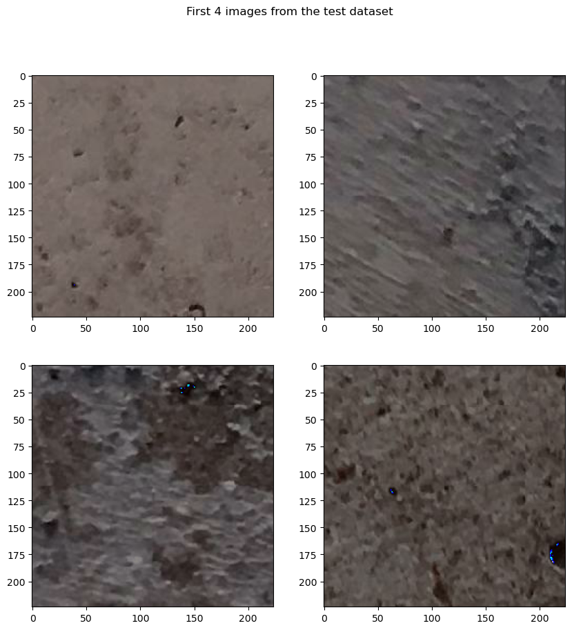

```python
import numpy as np
import matplotlib.pyplot as plt

first_batch_images = test_set.next()
images_px_first =first_batch_images[0]
images_classes_first =first_batch_images[1]

fig, axs = plt.subplots(nrows=2, ncols=2, figsize=(10, 10)) # define your figure and axes

ind = 0
for ax1 in axs:
    for ax2 in ax1:
        image_data = images_px_first[ind].astype(np.uint8)
        ax2.imshow(image_data)
        ind += 1

fig.suptitle('First 4 images from the test dataset')
plt.show()
```

[figure not shown]

```python
second_batch_images = test_set.next()
images_px_second =second_batch_images[0]
images_classes_second =second_batch_images[1]

fig, axs = plt.subplots(nrows=2, ncols=2, figsize=(10, 10)) # define your figure and axes

ind = 0
for ax1 in axs:
    for ax2 in ax1:
        image_data = images_px_second[ind].astype(np.uint8)
        ax2.imshow(image_data)
        ind += 1

fig.suptitle('Images 5 to 8  from the test dataset')
plt.show()
```

```python
#predict_VGG16 = model.predict_generator(test_set,steps=len(test_set), verbose=0).round(2)
```

```python
predict_VGG16 = model.predict(test_set,steps=len(test_set), verbose=0).round(2)
```

```python
classes1=model.predict(images_px_first)
classes1=np.argmax(classes1,axis=1)
print("Classes of images from first batch:",classes1)

classes2=model.predict(images_px_second)
classes2=np.argmax(classes2,axis=1)
print("Classes of images from first batch:",classes2)
```

```
Classes of images from first batch: [0 0 0 0 0]
Classes of images from first batch: [0 0 0 0 0]
```

```python
predicted_class_indices_vgg16=np.argmax(predict_VGG16,axis=1)

labels = (test_set.class_indices)
labels2 = dict((v,k) for k,v in labels.items())

predict_VGG16 = [labels2[k] for k in predicted_class_indices_vgg16]
```

```python
ind = 0
for i in range(0,10):
    print("Positive or negative image? Image number", ind+1, "is predicted",  predict_VGG16[ind])
    ind +=1
```

```
Positive or negative image? Image number 1 is predicted negative
Positive or negative image? Image number 2 is predicted negative
Positive or negative image? Image number 3 is predicted negative
Positive or negative image? Image number 4 is predicted negative
Positive or negative image? Image number 5 is predicted negative
Positive or negative image? Image number 6 is predicted negative
Positive or negative image? Image number 7 is predicted negative
Positive or negative image? Image number 8 is predicted negative
Positive or negative image? Image number 9 is predicted negative
Positive or negative image? Image number 10 is predicted negative
```

```python
ind = 0
images_classes_first = images_classes_first[0:5,1]

for i in range(0,5):
    if classes1[ind] == images_classes_first[ind]:
        print("First batch - Prediction for sample", ind+1, "is correct")
    else:
        print("First batch - Prediction for sample", ind+1, "is incorrect")
    ind +=1

ind = 0
images_classes_second = images_classes_second[0:5,1]

for i in range(0,5):
    if classes2[ind] == images_classes_second[ind]:
        print("Second batch - Prediction for sample", ind+1, "is correct")
    else:
        print("Second batch - Prediction for sample", ind+1, "is incorrect")
    ind +=1
```

```
First batch - Prediction for sample 1 is correct
First batch - Prediction for sample 2 is correct
First batch - Prediction for sample 3 is correct
First batch - Prediction for sample 4 is correct
First batch - Prediction for sample 5 is correct
Second batch - Prediction for sample 1 is correct
Second batch - Prediction for sample 2 is correct
Second batch - Prediction for sample 3 is correct
Second batch - Prediction for sample 4 is correct
Second batch - Prediction for sample 5 is correct
```

# Authors' rights

Machine Learning with Python course by IBM on Coursera: https://www.coursera.org/learn/machine-learning-with-python/

Completed and modified by Mathilde Marie Duville as part of the IBM Artificial Intelligence Engineering Professional Certificate and corresponding IBM badges. Please, follow the subsequent links to confirm the accreditation:

https://www.coursera.org/account/accomplishments/professional-cert/KSLW773DAATP?utm_source=link&utm_medium=certificate&utm_content=cert_image&utm_campaign=sharing_cta&utm_product=prof

https://www.credly.com/users/mathilde-marie-duville/badges

Author: Alex Aklson

This notebook is part of a course on **Coursera** called *AI Capstone Project with Deep Learning*. If you accessed this notebook outside the course, you can take this course online by clicking [here](https://cocl.us/DL0321EN_Coursera_Week4_LAB1).

Copyright © 2020 [IBM Developer Skills Network](https://cognitiveclass.ai/?utm_source=bducopyrightlink&utm_medium=dswb&utm_campaign=bdu). This notebook and its source code are released under the terms of the [MIT License](https://bigdatauniversity.com/mit-license/).